# Lecture 2: Factors and Matrices

### (Copied from R programming lecture notes, use for code reference only.)

## 1. Factors

- R supports factors which are **a special data type for managing categories of data**
- Identifying categorical variables is usually straightforward. These are the variables by which you might want to summarize some continuous data
- Categorical variables usually take on **a definite number of values**
- Many times R functions will convert character labels to factors by default but not always
- **Storing data as factors ensures that R modeling functions will treat such data correctly**

#### Let’s say we have some automobile data that tells us if a car has an automatic transmission (0) or a manual transmission (1). We store this into a vector called transvec

```r
mtcars$am
```

```
##  [1] 1 1 1 0 0 0 0 0 0 0 0 0 0 0 0 0 0 1 1 1 0 0 0 0 0 1 1 1 1 1 1 1
```

```r
transvec <- mtcars$am
transvec
```

```
##  [1] 1 1 1 0 0 0 0 0 0 0 0 0 0 0 0 0 0 1 1 1 0 0 0 0 0 1 1 1 1 1 1 1
```

```r
table(transvec)    #How many are Auto and Manual ? Count 'em up.
```

```
## transvec
##  0  1
## 19 13
```

```r
mytransfac <- factor(transvec, levels = c(0,1), labels = c("Auto","Man") )

levels(mytransfac)
```

```
## [1] "Auto" "Man"
```

```r
mytransfac
```

```
##  [1] Man  Man  Man  Auto Auto Auto Auto Auto Auto Auto Auto Auto Auto Auto
## [15] Auto Auto Auto Man  Man  Man  Auto Auto Auto Auto Auto Man  Man  Man
## [29] Man  Man  Man  Man
## Levels: Auto Man
```

#### R knows how to handle factors when doing plots. Here were get an X/Y plot and a Box Plot with very little work since R knows that mytransfac is a factor

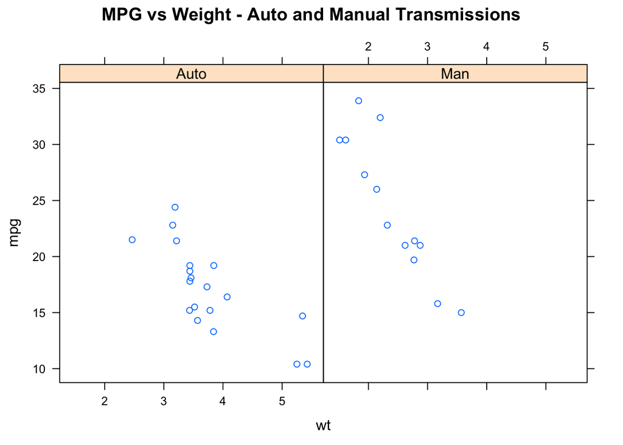

```r
library(lattice)
xyplot(mpg~wt | mytransfac, mtcars,
       main="MPG vs Weight - Auto and Manual Transmissions")
```

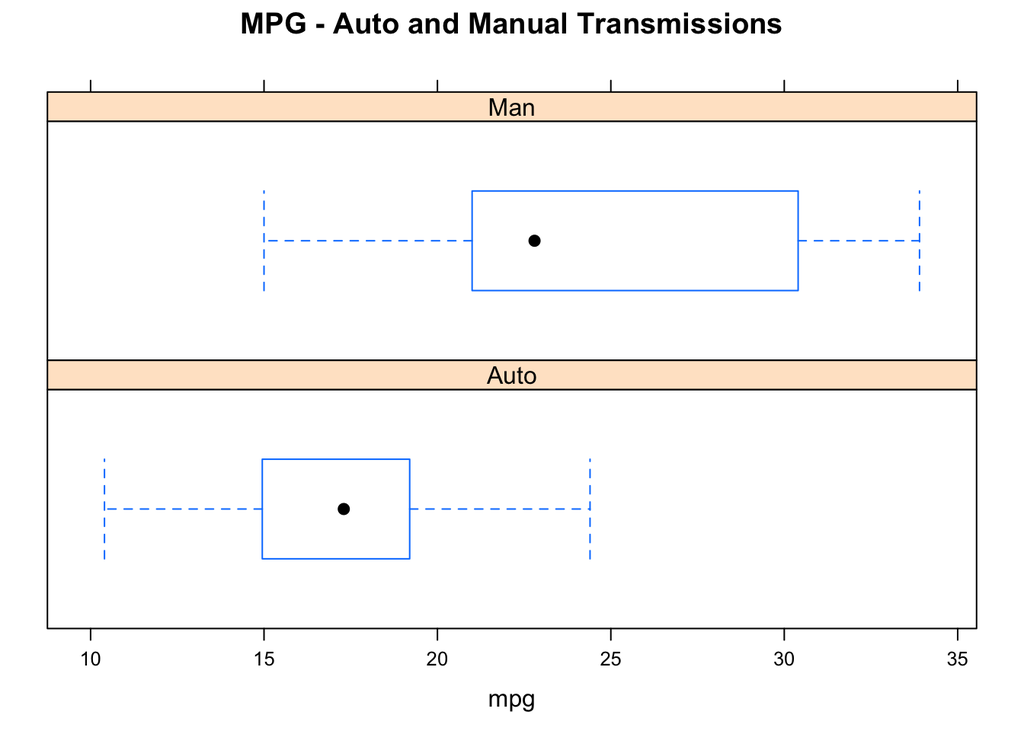

```r
bwplot(~mpg|mytransfac, mtcars,
       main="MPG - Auto and Manual Transmissions",layout=c(1,2))
```

### 1.1 Factor: aggregation

#### With our knowledge of factors and vectors we can do some basic aggregation using the `tapply` command. We have a factor vector called `mytransfac`.

#### Let’s summarize some MPG data that corresponds to the automobiles used in the mytransfac vector. So for each car we have its MPG figure and whether it has an automatic or manual transmission.

```r
mympg <- c(21,21,22.8,21.4,18.7,18.1,14.3,24.4,22.8,19.2,17.8,
16.4,17.3,15.2,10.4,10.4,14.7,32.4,30.4,33.9, 21.5,
15.5,15.2,13.3,19.2,27.3,26,30.4,15.8,19.7,15,21.4)

# tapply( continuous_value_to_summarize,  factor_or_grouping variable,
#function_for_summary)

tapply(mympg, mytransfac, mean)
```

```
##     Auto      Man
## 17.14737 24.39231
```

### 1.2 Factor: cut

#### It is sometimes useful to take a continuous variable and chop it up into intervals or categories for purposes of summary or grouping. R has a function to do this called `cut` to accomplish this.

#### Let’s work through some examples to understand what is going on. Let’s cut up the numbers between 0 and 10 into 4 distinct intervals

```r
cut(0:10,breaks=4)
```

```
##  [1] (-0.01,2.5] (-0.01,2.5] (-0.01,2.5] (2.5,5]     (2.5,5]
##  [6] (2.5,5]     (5,7.5]     (5,7.5]     (7.5,10]    (7.5,10]
## [11] (7.5,10]
## Levels: (-0.01,2.5] (2.5,5] (5,7.5] (7.5,10]
```

```r
table(cut(0:10,breaks=4))
```

```
##
## (-0.01,2.5]     (2.5,5]     (5,7.5]    (7.5,10]
##           3           3           2           3
```

```r
# Well that was cool but since we are creating 4 intervals we should probably name them
my.cut <- cut(0:10,breaks=4,labels=c("Q1","Q2","Q3","Q4"))

table(my.cut)
```

```
## my.cut
## Q1 Q2 Q3 Q4
##  3  3  2  3
```

```r
my.cut
```

```
##  [1] Q1 Q1 Q1 Q2 Q2 Q2 Q3 Q3 Q4 Q4 Q4
## Levels: Q1 Q2 Q3 Q4
```

```r
# But you can to take finer-grained control over how the intervals are made.
quantile(0:10)
```

```
##   0%  25%  50%  75% 100%
##  0.0  2.5  5.0  7.5 10.0
```

```r
table(cut(0:10,breaks=quantile(0:10),include.lowest=TRUE))
```

```
##
##  [0,2.5]  (2.5,5]  (5,7.5] (7.5,10]
##        3        3        2        3
```

### An example to use `cut`:

#### Let’s summarize some exam scores according to a typical grading system.

#### F: < 60, D: 60-70, C: 70-80, B:80-90, A:90-100

```r
set.seed(123)
exam.score <- runif(25,50,100)  # Simulate some scores

cut(exam.score,breaks=c(50,60,70,80,90,100))
```

```
##  [1] (60,70]  (80,90]  (70,80]  (90,100] (90,100] (50,60]  (70,80]
##  [8] (90,100] (70,80]  (70,80]  (90,100] (70,80]  (80,90]  (70,80]
## [15] (50,60]  (90,100] (60,70]  (50,60]  (60,70]  (90,100] (90,100]
## [22] (80,90]  (80,90]  (90,100] (80,90]
## Levels: (50,60] (60,70] (70,80] (80,90] (90,100]
```

```r
cut(exam.score,breaks=c(50,60,70,80,90,100),labels=c("F","D","C","B","A"))
```

```
##  [1] D B C A A F C A C C A C B C F A D F D A A B B A B
## Levels: F D C B A
```

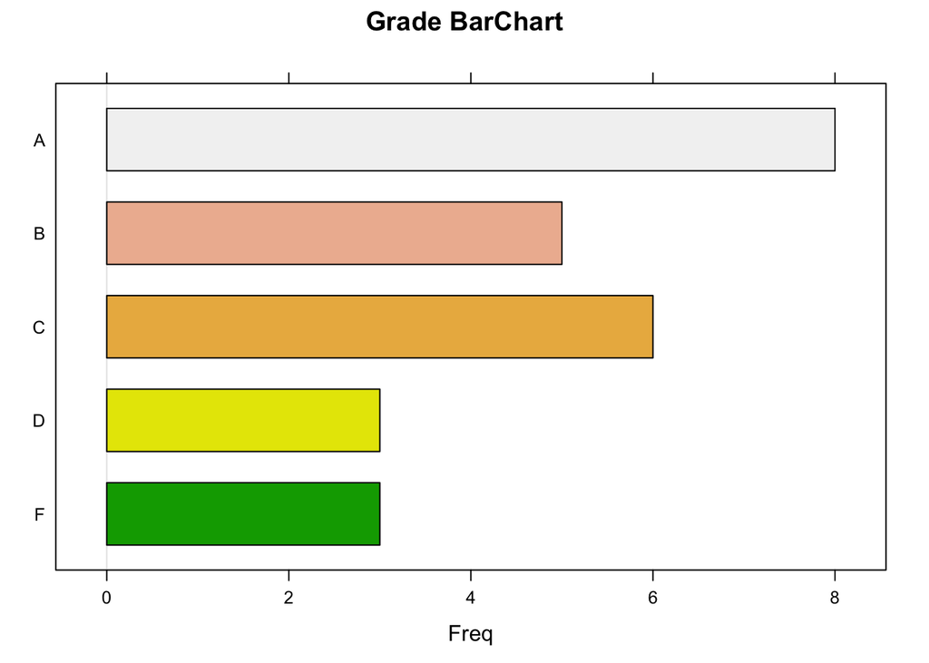

```r
my.table <- table(cut(exam.score,breaks=c(50,60,70,80,90,100),
                      labels=c("F","D","C","B","A")))

barchart(my.table,main="Grade BarChart",col=terrain.colors(5))
```

There are still some problems here:

- The intervals don’t exactly match the grading scheme
- A score of 90 will get a B when it should get an A
- Note the [ and ) characters show us if the interval boundary includes a score
- There is an argument that can help: `right`

```r
set.seed(123)
cut(exam.score,breaks=c(50,60,70,80,90,100))
```

```
##  [1] (60,70]  (80,90]  (70,80]  (90,100] (90,100] (50,60]  (70,80]
##  [8] (90,100] (70,80]  (70,80]  (90,100] (70,80]  (80,90]  (70,80]
## [15] (50,60]  (90,100] (60,70]  (50,60]  (60,70]  (90,100] (90,100]
## [22] (80,90]  (80,90]  (90,100] (80,90]
## Levels: (50,60] (60,70] (70,80] (80,90] (90,100]
```

```r
cut(exam.score,breaks=c(50,60,70,80,90,100),right=F)
```

```
##  [1] [60,70)  [80,90)  [70,80)  [90,100) [90,100) [50,60)  [70,80)
##  [8] [90,100) [70,80)  [70,80)  [90,100) [70,80)  [80,90)  [70,80)
## [15] [50,60)  [90,100) [60,70)  [50,60)  [60,70)  [90,100) [90,100)
## [22] [80,90)  [80,90)  [90,100) [80,90)
## Levels: [50,60) [60,70) [70,80) [80,90) [90,100)
```

```r
tmp = cut(exam.score,breaks=c(50,60,70,80,90,100),labels=c("F","D","C","B","A"))
table(tmp)
```

```
## tmp
## F D C B A
## 3 3 6 5 8
```

#### So if you don’t think that the cut command is cool then here is how you would have had to solve the problem - ughhh !

```r
set.seed(123)
exam.score <- runif(25,50,100)

acount <- 0
bcount <- 0
ccount <- 0
dcount <- 0
fcount <- 0
for (ii in 1:length(exam.score)) {

  if (exam.score[ii] < 60) {fcount = fcount + 1} else
    if ((exam.score[ii] >= 60) & (exam.score[ii] < 70)) {dcount = dcount + 1} else
      if ((exam.score[ii] >= 70) & (exam.score[ii] < 80)) {ccount = ccount +1} else
        if ((exam.score[ii] >= 80) & (exam.score[ii] < 90)) {bcount = bcount +1} else
          if ((exam.score[ii] >= 90) & (exam.score[ii] <= 100)) {acount = acount +1}
}
cat("fcount dcount ccount bcount acount")
```

```
## fcount dcount ccount bcount acount
```

```r
cat(fcount,dcount,ccount,bcount,acount)
```

```
## 3 3 6 5 8
```

#### Sometimes we want our factors to be ordered. For example, we intuitively know that January comes before February and so on. Can we get R to create ordered factors ?

```r
mons <- c("Jan","Feb","Mar","Apr","May","Jun","Jan",
          "Feb","May","Jun", "Apr","Mar")

my.fact.mons <- factor(mons)

my.fact.mons[1] < my.fact.mons[2]
```

```
## [1] NA
```

```r
levels(my.fact.mons)
```

```
## [1] "Apr" "Feb" "Jan" "Jun" "Mar" "May"
```

#### We can use argument `ordered=TRUE`.

```r
my.fact.mons <- factor(mons, levels=c("Jan","Feb","Mar","Apr","May","Jun"),
                       ordered=TRUE)
my.fact.mons
```

```
##  [1] Jan Feb Mar Apr May Jun Jan Feb May Jun Apr Mar
## Levels: Jan < Feb < Mar < Apr < May < Jun
```

```r
my.fact.mons[1] < my.fact.mons[2]
```

```
## [1] TRUE
```

```r
table(my.fact.mons)
```

```
## my.fact.mons
## Jan Feb Mar Apr May Jun
##   2   2   2   2   2   2
```

```r
levels(my.fact.mons)                       # This is what we want !
```

```
## [1] "Jan" "Feb" "Mar" "Apr" "May" "Jun"
```

#### Let’s do an analysis of variance on the mtcars data set variables MPG and number of gears, the latter of which takes on the values 3,4,5. So it is well suited to be a factor.

```r
head(mtcars)  # gear: the number of forward gears
```

```
##                    mpg cyl disp  hp drat    wt  qsec vs am gear carb
## Mazda RX4         21.0   6  160 110 3.90 2.620 16.46  0  1    4    4
## Mazda RX4 Wag     21.0   6  160 110 3.90 2.875 17.02  0  1    4    4
## Datsun 710        22.8   4  108  93 3.85 2.320 18.61  1  1    4    1
## Hornet 4 Drive    21.4   6  258 110 3.08 3.215 19.44  1  0    3    1
## Hornet Sportabout 18.7   8  360 175 3.15 3.440 17.02  0  0    3    2
## Valiant           18.1   6  225 105 2.76 3.460 20.22  1  0    3    1
```

```r
mtcars$gear <- factor(mtcars$gear)  # Turn gear into a factor
aov.ex1 = aov(mpg ~ gear,mtcars)
summary(aov.ex1)
```

```
##             Df Sum Sq Mean Sq F value   Pr(>F)
## gear         2  483.2  241.62    10.9 0.000295 ***
## Residuals   29  642.8   22.17
## ---
## Signif. codes:  0 '***' 0.001 '**' 0.01 '*' 0.05 '.' 0.1 ' ' 1
```

```r
my.tukey <- TukeyHSD(aov.ex1,"gear")
# Tukey Honest Significant Difference test: https://en.wikipedia.org/wiki/Tukey%27s_range_test
my.tukey
```

```
##   Tukey multiple comparisons of means
##     95% family-wise confidence level
##
## Fit: aov(formula = mpg ~ gear, data = mtcars)
##
## $gear
##          diff        lwr       upr     p adj
## 4-3  8.426667  3.9234704 12.929863 0.0002088
## 5-3  5.273333 -0.7309284 11.277595 0.0937176
## 5-4 -3.153333 -9.3423846  3.035718 0.4295874
```

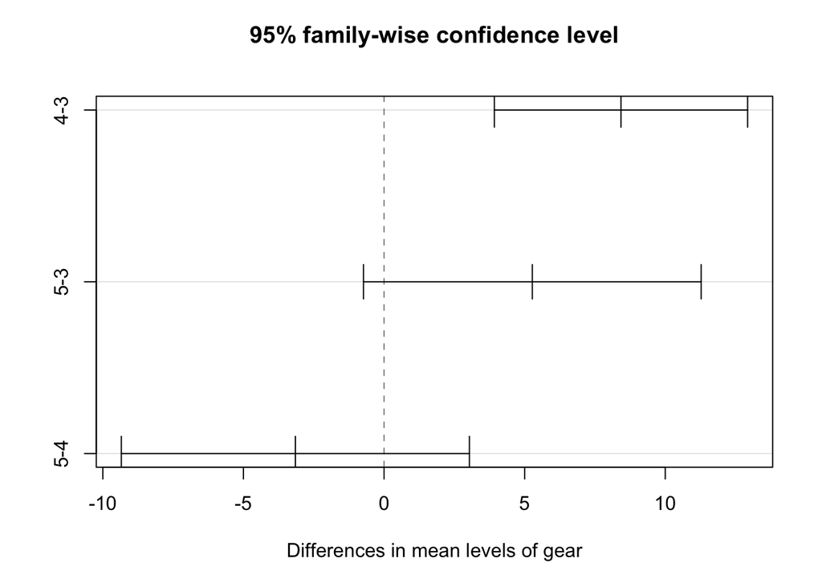

```r
plot (my.tukey)
```

```r
# Differences between Gears are significant at the five percent level if the
# confidence interval around the estimation of the difference does not
# contain zero
```

## 2. Matrices

- **Matrices are important mathematical structures for which R has excellent support**
- **Matrices are ideal for storing information on scientific data**
- **Think of a matrix as being a vector with dimensions**
- **There are two common ways to create a matrix**

### 2.1 `dim()` and `matrix()`

#### Using the `dim()` function. You can think of the following vector as being a matrix with one row and twelve columns.

```r
# To create, for example, a 3x4 matrix use the dim() function to adjust thedimensions of the vector
myvec <- c(1:12)

dim(myvec) <- c(3,4)
myvec
```

```
##      [,1] [,2] [,3] [,4]
## [1,]    1    4    7   10
## [2,]    2    5    8   11
## [3,]    3    6    9   12
```

```r
# Note that columns are "filled" before rows. Note also that the requested dimension must make sense with the available number of elements
dim(myvec) <- c(5,4)
```

```
## Error in dim(myvec) <- c(5, 4): dims [product 20] do not match the length of object [12]
```

#### Using the `matrix()` function.

```r
# You can use the `nrow` and `ncol` arguments to
# explicity specify the desired number of rows and columns.
mymat <- matrix( 1:6, nrow=3, ncol=2)
mymat
```

```
##      [,1] [,2]
## [1,]    1    4
## [2,]    2    5
## [3,]    3    6
```

```r
# You can also request that the rows get filled
# first as opposed to the columns:
mymat <- matrix( 1:6, nrow=3, ncol=2, byrow=TRUE)
mymat
```

```
##      [,1] [,2]
## [1,]    1    2
## [2,]    3    4
## [3,]    5    6
```

### 2.2 Matrices - Naming Rows and Columns

#### It is useful to name the rows and columns of matrices.

```r
set.seed(123)
X <- matrix(rpois(20,1.5),nrow=4)
X
```

```
##      [,1] [,2] [,3] [,4] [,5]
## [1,]    1    4    1    2    1
## [2,]    2    0    1    2    0
## [3,]    1    1    4    0    1
## [4,]    3    3    1    3    4
```

```r
# Let's say that these refer to four trials. We want to label the rows
# "Trial.1", "Trial.2", etc.
rownames(X) <- paste("Trial",1:nrow(X),sep=".")
X
```

```
##         [,1] [,2] [,3] [,4] [,5]
## Trial.1    1    4    1    2    1
## Trial.2    2    0    1    2    0
## Trial.3    1    1    4    0    1
## Trial.4    3    3    1    3    4
```

```r
# We can something similar with the columns
colnames(X) <- paste("P",1:ncol(X),sep=".")
X
```

```
##         P.1 P.2 P.3 P.4 P.5
## Trial.1   1   4   1   2   1
## Trial.2   2   0   1   2   0
## Trial.3   1   1   4   0   1
## Trial.4   3   3   1   3   4
```

```r
# Example taken from\The R Book - Michael J. Crawley
```

#### Names provide an intutive way to index into a matrix structure.

```r
drug.names <- c("aspirin","paracetamol","nurofen","hedex","placebo")

colnames(X) <- drug.names

X
```

```
##         aspirin paracetamol nurofen hedex placebo
## Trial.1       1           4       1     2       1
## Trial.2       2           0       1     2       0
## Trial.3       1           1       4     0       1
## Trial.4       3           3       1     3       4
```

```r
X['Trial.1',]   # Gets all columns for Trial #1
```

```
##     aspirin paracetamol     nurofen       hedex     placebo
##           1           4           1           2           1
```

```r
X['Trial.1','nurofen']
```

```
## [1] 1
```

```r
X
```

```
##         aspirin paracetamol nurofen hedex placebo
## Trial.1       1           4       1     2       1
## Trial.2       2           0       1     2       0
## Trial.3       1           1       4     0       1
## Trial.4       3           3       1     3       4
```

```r
X[,'nurofen']                     # Get all Trials for nurofen
```

```
## Trial.1 Trial.2 Trial.3 Trial.4
##       1       1       4       1
```

```r
X[,'nurofen',drop=FALSE]   # Preserves matrix structure if desired
```

```
##         nurofen
## Trial.1       1
## Trial.2       1
## Trial.3       4
## Trial.4       1
```

#### It is more common to use numeric indexing especially if you are accessing parts of a matrix from a program.

```r
set.seed(123)
X <- matrix(rpois(9,1.5),nrow=3)
X
```

```
##      [,1] [,2] [,3]
## [1,]    1    3    1
## [2,]    2    4    3
## [3,]    1    0    1
```

```r
X[1,1]     # First row, First Column
```

```
## [1] 1
```

```r
X[2,2]     # Second row, Second Column
```

```
## [1] 4
```

```r
X[3,3]     # Third row, Third column
```

```
## [1] 1
```

```r
diag(X)     # Ah, there is a function that gets the diagonal.
```

```
## [1] 1 4 1
```

```r
X[1:2,1]     # Gets First and second rows and the first column
```

```
## [1] 1 2
```

```r
X[1:2,2]     # Gets First and second rows and the second column
```

```
## [1] 3 4
```

```r
X[1:2,]      # Gets First and second rows and ALL columns
```

```
##      [,1] [,2] [,3]
## [1,]    1    3    1
## [2,]    2    4    3
```

```r
# Extracting information from a matrix is an important skill. Practice makes perfect.
X[,c(1,3)]     # Get all rows but only columns 1 and 3
```

```
##      [,1] [,2]
## [1,]    1    1
## [2,]    2    3
## [3,]    1    1
```

```r
X[,-2]   # Same effect as above. Get all rows and columns except 2
```

```
##      [,1] [,2]
## [1,]    1    1
## [2,]    2    3
## [3,]    1    1
```

```r
# Remember that a matrix is just a vector with dimensions so you could
# index into a matrix using single bracket notation.

X[1:4]
```

```
## [1] 1 2 1 3
```

```r
X >= 2
```

```
##       [,1]  [,2]  [,3]
## [1,] FALSE  TRUE FALSE
## [2,]  TRUE  TRUE  TRUE
## [3,] FALSE FALSE FALSE
```

```r
X[X >= 2]   # Returns which values are greater or equal to 2
```

```
## [1] 2 3 4 3
```

```r
which(X >= 2)   # Returns which elements are greater or equal to 2
```

```
## [1] 2 4 5 8
```

```r
X %% 2 == 0          # Returns a logical matrix
```

```
##       [,1]  [,2]  [,3]
## [1,] FALSE FALSE FALSE
## [2,]  TRUE  TRUE FALSE
## [3,] FALSE  TRUE FALSE
```

```r
X[ X %% 2 == 0 ]   # Finds the actual element values
```

```
## [1] 2 4 0
```

```r
X[X %%  2 == 0] <- 99
```

#### There are two functions called row and col that return the numeric row and column, respectively of the matrix.

```r
X <- matrix(rpois(9,1.5),nrow=3)

X
```

```
##      [,1] [,2] [,3]
## [1,]    1    2    3
## [2,]    4    2    1
## [3,]    1    0    0
```

```r
row(X)               # The values correspond to the actual row number
```

```
##      [,1] [,2] [,3]
## [1,]    1    1    1
## [2,]    2    2    2
## [3,]    3    3    3
```

```r
col(X)               # The values correspond to the actual col number
```

```
##      [,1] [,2] [,3]
## [1,]    1    2    3
## [2,]    1    2    3
## [3,]    1    2    3
```

```r
row(X) == col(X)
```

```
##       [,1]  [,2]  [,3]
## [1,]  TRUE FALSE FALSE
## [2,] FALSE  TRUE FALSE
## [3,] FALSE FALSE  TRUE
```

```r
X[row(X) == col(X)]
```

```
## [1] 1 2 0
```

```r
X[row(X) == col(X)] <- 0  # Put zeroes in the diagonal
```

### 2.3 `rbind()` and `cbind()`

We can easily bind two matrices using `rbind()` and `cbind()`

```r
x1 <- matrix(1:9, 3, 3)
x2 <- matrix(-1:-9, 3, 3)

rbind(x1, x2)  # row-bind two matrices
```

```
##      [,1] [,2] [,3]
## [1,]    1    4    7
## [2,]    2    5    8
## [3,]    3    6    9
## [4,]   -1   -4   -7
## [5,]   -2   -5   -8
## [6,]   -3   -6   -9
```

```r
cbind(x1, x2)  # column-bind two matrices
```

```
##      [,1] [,2] [,3] [,4] [,5] [,6]
## [1,]    1    4    7   -1   -4   -7
## [2,]    2    5    8   -2   -5   -8
## [3,]    3    6    9   -3   -6   -9
```

### 2.4 calculate the sum and mean of each row/column

```r
x1
```

```
##      [,1] [,2] [,3]
## [1,]    1    4    7
## [2,]    2    5    8
## [3,]    3    6    9
```

```r
rowSums(x1)  # calculate the sum of each row
```

```
## [1] 12 15 18
```

```r
rowMeans(x1) # calculate the mean of each row
```

```
## [1] 4 5 6
```

```r
colSums(x1) # calculate the sum of each column
```

```
## [1]  6 15 24
```

```r
colMeans(x1)  # calculate the mean of each column
```

```
## [1] 2 5 8
```

#### Be careful if the matrix has missing values

```r
# There are functions optimized specifcally for use with matrices. They are
# very fast and work well on large matrices.

# However be careful if the matrix has missing data in wich case you will
# need to include the na.rm=TRUE arugement.
X
```

```
##      [,1] [,2] [,3]
## [1,]    0    2    3
## [2,]    4    0    1
## [3,]    1    0    0
```

```r
X[1,2] <- NA

colMeans(X)
```

```
## [1] 1.666667       NA 1.333333
```

```r
colMeans(X, na.rm=TRUE)
```

```
## [1] 1.666667 0.000000 1.333333
```

### 2.5 `apply()`

#### There is a function called `apply` which simplifies looping over the rows or columns of a matrix. The " `apply` family" of functions is important in R.

```r
X <- matrix(rpois(9,1.5),nrow=3)
X
```

```
##      [,1] [,2] [,3]
## [1,]    1    2    2
## [2,]    4    2    2
## [3,]    3    5    1
```

```r
# apply(matrix, a number 1 or 2, function name)

apply(X,1,max)            # 1 is for rows
```

```
## [1] 2 4 5
```

```r
apply(X,2,max)            # 2 is for columns
```

```
## [1] 4 5 2
```

```r
apply(X, 1, function(x) sqrt(sum(x)))
```

```
## [1] 2.236068 2.828427 3.000000
```

### 2.6 Matrices - Linear Algebra

#### R supports common linear algebra operations

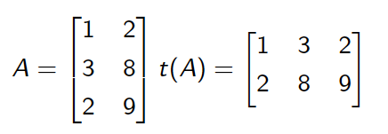

```r
A <- matrix(c(1,3,2,2,8,9),3,2)
A
```

```
##      [,1] [,2]
## [1,]    1    2
## [2,]    3    8
## [3,]    2    9
```

```r
# transpose
t(A)
```

```
##      [,1] [,2] [,3]
## [1,]    1    3    2
## [2,]    2    8    9
```

```r
B <- matrix(1:9,3,3)

diag(B)             # Fetches the diagonal
```

```
## [1] 1 5 9
```

```r
diag(c(1,2,3))      # Creates a matrix with 1,2,3 on the diagonal
```

```
##      [,1] [,2] [,3]
## [1,]    1    0    0
## [2,]    0    2    0
## [3,]    0    0    3
```

```r
diag(1,4)           # Creates a 4 x 4 Indentity matrix
```

```
##      [,1] [,2] [,3] [,4]
## [1,]    1    0    0    0
## [2,]    0    1    0    0
## [3,]    0    0    1    0
## [4,]    0    0    0    1
```

#### The inverse of a n x n matrix A is the matrix B (which is also n x n) that when multiplied by A gives the identity matrix

```r
A <- matrix(1:4,2,2)
A
```

```
##      [,1] [,2]
## [1,]    1    3
## [2,]    2    4
```

```r
B = solve(A)  ## the inverse of A

B
```

```
##      [,1] [,2]
## [1,]   -2  1.5
## [2,]    1 -0.5
```

```r
A %*% B            # We get the identity matrix
```

```
##      [,1] [,2]
## [1,]    1    0
## [2,]    0    1
```

#### Suppose we have the following system of equations

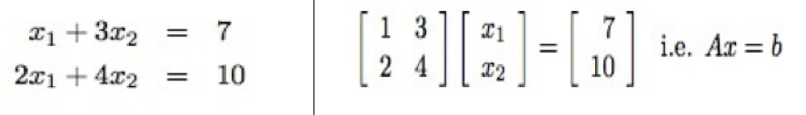

```r
A
```

```
##      [,1] [,2]
## [1,]    1    3
## [2,]    2    4
```

```r
b = c(7,10)
x = solve(A) %*% b
x
```

```
##      [,1]
## [1,]    1
## [2,]    2
```

#### Eigen values/vectors show up a lot in math - like with Principal Components

```r
my.wines <- read.csv("https://www.dropbox.com/s/429p4p5jkaa7i6t/wine.csv?dl=1",header=T)
my.scaled.wines <- scale(my.wines[,-1])   # Scale the data
my.cov <- cor(my.wines[,-1])       # Get the covariance matrix
my.eigen <- eigen(my.cov)            # Now find the eigen values/vectors

options(digits=3)
my.eigen                            # Check out the Eigen values and vectors
```

```
## eigen() decomposition
## $values
##  [1] 4.706 2.497 1.446 0.919 0.853 0.642 0.551 0.348 0.289 0.251 0.226
## [12] 0.169 0.103
##
## $vectors
##           [,1]     [,2]    [,3]    [,4]    [,5]    [,6]    [,7]    [,8]
##  [1,] -0.14433 -0.48365 -0.2074 -0.0179 -0.2657  0.2135  0.0564  0.3961
##  [2,]  0.24519 -0.22493  0.0890  0.5369  0.0352  0.5368 -0.4205  0.0658
##  [3,]  0.00205 -0.31607  0.6262 -0.2142 -0.1430  0.1545  0.1492 -0.1703
##  [4,]  0.23932  0.01059  0.6121  0.0609  0.0661 -0.1008  0.2870  0.4280
##  [5,] -0.14199 -0.29963  0.1308 -0.3518  0.7270  0.0381 -0.3229 -0.1564
##  [6,] -0.39466 -0.06504  0.1462  0.1981 -0.1493 -0.0841  0.0279 -0.4059
##  [7,] -0.42293  0.00336  0.1507  0.1523 -0.1090 -0.0189  0.0607 -0.1872
##  [8,]  0.29853 -0.02878  0.1704 -0.2033 -0.5007 -0.2586 -0.5954 -0.2333
```

[output cut: 19 more lines]